# Enron Fraud Investigation

## 1.0 Introduction

In 2002 Enron was one of the tenth largest companies in the U.S. This multi-billion dollar company suddenly collapsed; thousands of people lost their jobs, and some of them went to jail. The company have been identified as carrying out corporate fraud on a massive scale. The goal of the project is to identify persons of interest (POIs) from the Enron dataset consisting of financial and email information using machine learning algorithms.

## 2.0 The Enron Dataset

### Summary of Section

The unedited dataset contained features for 145 senior persons who worked at Enron. The dataset contained both financial and email information. The financial information was taken from the document *enron61702insiderpay.pdf*, it contained data such as salary and expenses. This information is useful for discriminating POI from non-POI persons as it is more likely that the more senior persons were more highly rewarded finanically - these are also more likely to be the persons behind the corruption in the company. The email information contained items such as communication between POI and non-POI persons. Again this information could help identfy POIs as POIs are more likely to communicate with other POIs rather than non-POI persons.

There were 146 entries in the database dictionary, of these only 18 were POIs - an example of a unbalanced dataset. There were 2190 dataset values but only 1228 contained values, the rest were set as *NaN*. During the outlier identification stage a spreadsheet quirk named *TOTAL* was found, this was removed as it did not apply to any of the Enron persons. Several financial outliers were discovered, these were found to be financial data from some of the POIs such as Kenneth Lay, Jeffrey Skilling and others. These outliers were not removed as they were considered to be valid values for the machine learning algorithms.

```python
%matplotlib inline
import sys
import pickle
sys.path.append("../tools/")
import pylab
import scipy.stats as stats
import matplotlib.pyplot as plt
import numpy as np
from feature_format import featureFormat, targetFeatureSplit
from tester import test_classifier, dump_classifier_and_data
from json import dumps
from time import time
import math
import sklearn
import json
from sklearn.metrics import accuracy_score
from sklearn.grid_search import GridSearchCV
from sklearn.metrics import precision_score
from sklearn.metrics import recall_score
from sklearn.decomposition import PCA
from sklearn.naive_bayes import GaussianNB
from sklearn.tree import DecisionTreeClassifier
from sklearn.svm import LinearSVC
from sklearn.ensemble import AdaBoostClassifier
from sklearn.ensemble import RandomForestClassifier
from sklearn.neighbors import KNeighborsClassifier
from sklearn.linear_model import LogisticRegression
from sklearn import preprocessing
from sklearn.pipeline import Pipeline
from sklearn.feature_selection import SelectFromModel
from sklearn.feature_selection import SelectKBest, f_classif,SelectPercentile

import pprint

### The first feature must be "poi".
poi = ['poi']

features_financial = [
             #   "bonus",
                "deferral_payments",
                "deferred_income",
             #   "director_fees",
             #   "exercised_stock_options",
             #   "expenses",
             #  "loan_advances",
             #   "long_term_incentive",
             #  "other",
             #   "restricted_stock",
             #   "restricted_stock_deferred",
             #   "salary",
             #   "total_payments",
             #   "total_stock_value"
                ]
features_email = [
                "from_messages",
                "from_poi_to_this_person",
                "from_this_person_to_poi",
                "shared_receipt_with_poi",
                "to_messages",
                #"email_address"
                ]

features_list_new = [
    #    "ratio_poi_messages",
    #    "salary_log",
    #    "bonus_log",
    #    "total_payments_log",
    #    "deferral_payments_log",
    #    "deferred_income_log",
    #    "director_fees_log",
    #    "exercised_stock_options_log",
    #    "expenses_log",
    #    "loan_advances_log",
    #    "long_term_incentive_log",
    #    "other_log",
    #    "restricted_stock_deferred_log",
    #    "restricted_stock_log",
    #    "total_stock_value_log",
    #    "ratio_bonus_total_payments",
    #    "ratio_salary_total_payments"
]

features_list = poi + features_financial + features_email

### Load the dictionary containing the dataset
with open("final_project_dataset.pkl", "r") as data_file:
    data_dict = pickle.load(data_file)

my_dataset = data_dict
### Extract features and labels from dataset for local testing
data = featureFormat(my_dataset, features_list, sort_keys = True)
```

### 2.1 Features Processing

The 21 features of the dataset consist of three catergories; financial, email and poi label.

1. **Financial features:** *salary,total_payments, bonus, exercised_stock_options, deferral_payments, restricted_stock,restricted_stock_deferred, total_stock_value, expenses', loan_advances, other, director_fees,deferred_income, long_term_incentive*. All these are numerical data in units of US dollars
2. **Email features:** *to_messages, shared_receipt_with_poi, from_messages, from_this_person_to_poi, from_poi_to_this_person and email_address*. All these are numerical count values except text string email_address
3. **POI feature**: *poi*. Boolean data value - these are the target labels for the machine learning algoritms

We can look at the data for one of the most senior Enron employees, Kenneth Lay:

```python
print json.dumps(data_dict['LAY KENNETH L'], indent=4, sort_keys=True)
```

```
{
    "bonus": 7000000,
    "deferral_payments": 202911,
    "deferred_income": -300000,
    "director_fees": "NaN",
    "email_address": "kenneth.lay@enron.com",
    "exercised_stock_options": 34348384,
    "expenses": 99832,
    "from_messages": 36,
    "from_poi_to_this_person": 123,
    "from_this_person_to_poi": 16,
    "loan_advances": 81525000,
    "long_term_incentive": 3600000,
    "other": 10359729,
    "poi": true,
    "restricted_stock": 14761694,
    "restricted_stock_deferred": "NaN",
    "salary": 1072321,
    "shared_receipt_with_poi": 2411,
    "to_messages": 4273,
    "total_payments": 103559793,
    "total_stock_value": 49110078
}
```

Let's look a *total_payments* as an example. For a better feel for the data, we can plot the data, for the moment set the *NaN* values to zero for plotting purposes.

```python
#generate temporary value for analysis
def generate_temp_values(input_data):
    total_payments = []
    for value in input_data.values():
        if value['total_payments']:
            if value['total_payments'] == 'NaN':
                value['total_payments'] = 0
            total_payments.append(value['total_payments'])
    return total_payments
```

```python
def plot_figure(input_data):
    fig = plt.figure(figsize=[8, 7], dpi=100)
    ax = fig.add_subplot(111)
    stats.probplot(input_data,dist='norm',plot=pylab)
    ax.set_title("Probability plot of total_payments",fontsize=12, fontweight='bold')
    ax.set_xlabel("Quantiles", fontsize=12, fontweight='bold')
    ax.set_ylabel("Ordered Values", fontsize=12, fontweight='bold')
    ax.grid(True)
    pylab.show()
```

The probability plot below shows how the boundaries associated with empirical percentiles in the data compare to the boundaries for the same percentiles of a Gaussian distribution. If the data being analyzed comes from a Gaussian distribution, the *total_payments* plotted will lie on a straight line. The probability plot shows that a point of the *total_payments* data is very far from the line, giving a low R-squared value. That means that the tails data contain more examples than the tails of a Gaussian density.

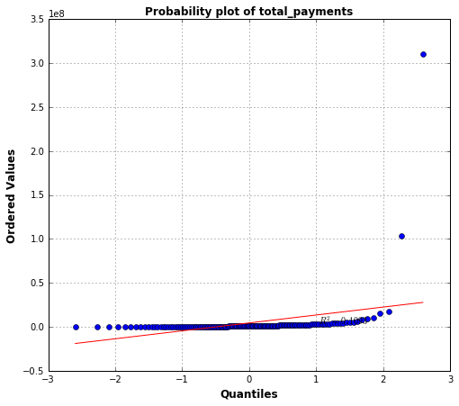

```python
#generate probabilty plot for total_payments, showing the exterme outlier for key 'TOTAL'
temp_data = np.asarray(generate_temp_values(data_dict))
plot_figure(temp_data)
```

From the figure we have some outliers, after further investigation of the dataset the values of the extreme outlier in the figure above is caused by abnormaility *TOTAL*, which is a key in the dataset. This value was found to be the sum of all *total_payments* in the dataset. A strange feature was the python key *THE_TRAVEL_AGENCY_IN_THE_PARK* which did not correspond to a Enron executive. These keys were removed from the dataset.

#### Removing Outliers

```python
#remove the outliers
outliers = ['TOTAL', 'THE TRAVEL AGENCY IN THE PARK']
for outlier in outliers:
    data_dict.pop(outlier, 0)
```

Replot the figure with *TOTAL* removed

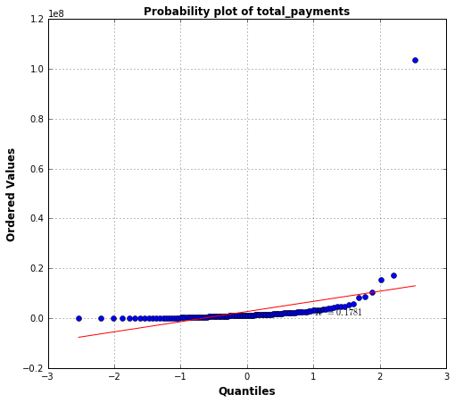

```python
#Reload the dataset with the removed dictionary keys
my_dataset = data_dict
data = featureFormat(my_dataset, features_list, sort_keys = True)
temp_data_2 = np.asarray(generate_temp_values(data_dict))
plot_figure(temp_data_2)
```

Remaining outliers are found to be actual salary values for the big Enron earners such as Kenneth Lay, we can leave these in the dataset. As expected we have a closer match to regression line after removal of abnormaility outlier. We have a classic example of monetary amounts having a skewed distribution - the log of monetary amounts data are often normally distributed, taking the log of the data can help to restore symmetry.

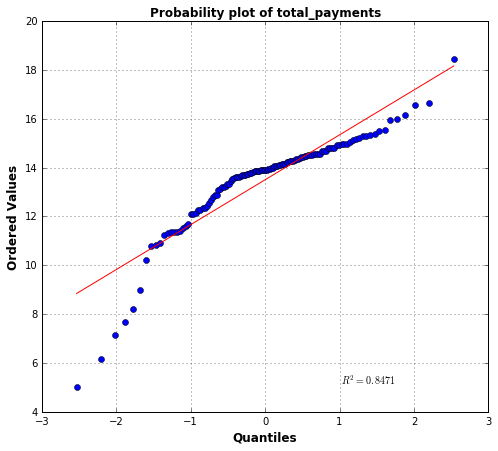

```python
#convert to float for plotting
temp_data_2 = temp_data_2.astype(float)
for i in range(len(temp_data_2)):
    temp_data_2[i] = math.log(temp_data_2[i])
plot_figure(temp_data_2)
```

After taking log of the skewed monetary values, we can see a more normally distributed relationship. The R-squared value is now much closer to 1. If required this technique can be applied to the other monetary values in the dataset to create other dataset variables.

## 3.0 Feature Selection

### Summary of Section

POIs are more likely to communicate with other persons of interest and also to be rewarded more signifcantly in monetary terms. To this end new features were added to the dataset.

A new feature, the ratio of POI messages was created. The number of POI messages divided by the total number of messages from this person.

From Section 2.0 we showed that by taking the log of monetary values we can obtain a more normal distribution as an aid to help prediction, this was applied to make new log based monetary values.

Two new finanical features were added namely *ratio_bonus_total_payments* and *ratio_salary_total_payments* these new features are the ratios of bonus and salary to total payments. This was done to emphasise a possible relationship between salary and bonus received in relation to total payments. This resulted in 17 new features, though a considerable number are *NaN* as a significant number of the parent features were *NaN*

The feature *email_address* was removed from the database as it was a text string and not considered relevant here.

In order to aid feature selection an automated function SelectKBest was used to determine importance of the features. PCA was also used to reduce the dimensionality of the dataset with the aim of determining a underlying trend to POI investigation. Because of the variation in ranges of the features used MinMax scaling was also applied to normalise the features.

After testing in later stages, the log values did not bring any discernible increase in test results especially as MinMax scaling was employed, therefore the log values were not included in the final testing stages.

### 3.1 Adding of New Features

```python
#make new variables based on emails
for name in data_dict:
    try:
        total_messages = data_dict[name]['from_messages'] + data_dict[name]['to_messages']
        poi_related_messages = data_dict[name]["from_poi_to_this_person"] +\
                                    data_dict[name]["from_this_person_to_poi"] +\
                                    data_dict[name]["shared_receipt_with_poi"]
        data_dict[name]['ratio_poi_messages'] = (1.0 * poi_related_messages / total_messages)
    except:
        data_dict[name]['ratio_poi_messages'] = 'NaN'
```

```python
#take log of monetary based features
for name in data_dict:
    for feature in features_financial:
        try:
            data_dict[name][feature + '_log'] = math.log(data_dict[name][feature]+1)
        except:
            data_dict[name][feature + '_log'] = 'NaN'
```

```python
#make ratio of bonus to total payments
for name in data_dict:
    try:
        data_dict[name]['ratio_bonus_total_payments'] = 1.0 *data_dict[name]['bonus']\
        / data_dict[name]['total_payments']
    except:
        data_dict[name]['ratio_bonus_total_payments'] = 'NaN'
```

```python
#make ratio of salary to total payments
for name in data_dict:
    try:
        data_dict[name]['ratio_salary_total_payments'] = 1.0 *data_dict[name]['salary']\
        / data_dict[name]['total_payments']
    except:
        data_dict[name]['ratio_salary_total_payments'] = 'NaN'
```

### 3.2 Feature Scaling and Automated Feature Selection

Normalise the data using MinMaxscaler function. Apply the SelectKBest automated selection function to aid in feature selection. PCA was used to reduce the amount of features but it was not used in the latter stages of testing. The features used in the final stages were:

```python
features_list = poi  + features_financial+ features_list_new + features_email
print features_list
```

```
['poi', 'deferral_payments', 'deferred_income', 'from_messages', 'from_poi_to_this_person', 'from_this_person_to_poi', 'shared_receipt_with_poi', 'to_messages']
```

```python
### Store to my_dataset for easy export below.
my_dataset = data_dict

### Extract features and labels from dataset for local testing
data = featureFormat(my_dataset, features_list, sort_keys = True)
labels, features = targetFeatureSplit(data)

#apply min max scaling
scaler = preprocessing.MinMaxScaler()
features = scaler.fit_transform(features)

k = 15
def generate_k_best(data_dict, features_list, k):
    #Run SelectKbest - returns a dictionary of best features
    select_k_best = SelectKBest(k=k)
    select_k_best.fit(features, labels)
    scores = select_k_best.scores_
    unsorted_pairs = zip(features_list[1:], scores)
    sorted_pairs = list(reversed(sorted(unsorted_pairs, key=lambda x: x[1])))
    k_best_features = dict(sorted_pairs[:k])
    return k_best_features

#k_best = generate_k_best(data_dict, features_list, 15)
#print "{0} best features are: {1}\n".format(k, k_best.keys())
#features_list = poi + k_best.keys()
print features_list
```

```
['poi', 'deferral_payments', 'deferred_income', 'from_messages', 'from_poi_to_this_person', 'from_this_person_to_poi', 'shared_receipt_with_poi', 'to_messages']
```

### 3.3 Apply PCA

```python
#uncomment lines below to include PCA
#pca = PCA(n_components=20, whiten=True,svd_solver = 'auto').fit(features)
#features = pca.transform(features)
```

## 4.0 Classification

### Summary of Section

To get an approximation of which classifiers to use and to give some indications of how long they make take to classify the data, some testing was done using *cross_val_score* as a test metric. Perhaps the most simple classifier Gaussian Naive Bayes gave the worst performance. After this various classifiers were used.

The test procedure can be summarised as:

1. Use SelectKBest to select and reduce features
2. Try various classifiers
3. Use GridSearchCV to determine optimum classifer parameters (f1 score) for various classifiers
4. Return to Step 1 if Precision and Recall threshold (0.3) not reached
5. If necessary refine manually to improve performance

The classifiers tried were:

- Gaussian Naive Bayes
- Decision Tree Classifer
- Logistic Regression
- Linear SVC (SVM)
- AdaBoost

These were used as I wanted to try different types of classifier such as simple Bayes,Tree Based methods, Regression and Support Vector Machines. Some of the results are summaried below, these classifiers used the original and three new engineered features:

| **Classifier** | **Precision** | **Recall** | **F1** |
| --- | --- | --- | --- |
| AdaBoost | 0.343 | 0.273 | 0.304 |
| DecisionTree | 0.238 | 0.219 | 0.228 |
| GaussianNB | 0.226 | 0.395 | 0.288 |
| Logistic Regression | 0.382 | 0.491 | 0.429 |

The best results came from Linear SVC and Logistic Regression classifiers. The table below displays results from GridSearchCV for the Logistic Regression Classifier, with SelectKBest, original and original plus 3 new features.

[output not shown]

SelectKBest and adding new features did not bring any improvement in the scores. By adding new features based on monetary and poi email information there was a degradation in the results. In particular the recall score dropped signifcantly from 0.594 to 0.491; the algorithm is getting worse at identifying the POIs with these new features added.

The parameters chosen by GridsearchCV for the original features were:

- LogisticRegression(C=1, class_weight='balanced', dual=False, fit_intercept=True, intercept_scaling=1, max_iter=100, multi_class='ovr', n_jobs=1, penalty='l1', random_state=None, solver='liblinear', tol=0.0001, verbose=0, warm_start=False)

The best results were obtained with penalty set to l1, both for LinearSVC and Logisitic Regression clssifiers, with the penalty set to l2 the results were poor. Linear models penalized with the L1 norm have sparse solutions: many of their estimated coefficients are zero. Indeed the goal is to reduce the dimensionality of the data to use with another classifier, they can be used along with feature_selection. With SVMs and Logistic Regression, the parameter *C* controls the sparsity: the smaller *C* the fewer features selected. In this case parameter *C* = 1.0, meant many of the feature coefficients would have been set to zero. This indicates the best results were obtained by a method which effectively reduces the number of feaures by setting their values to zero.

Automating the algorithm tuning process in GridSearchCV was very useful. It identified certain parameters as more important, such as the l1-norm.

To see if the scores could be increased, the features were manually selected by trial and error, focusing on the email features and adding some financial features. After considerable effort only seven original features were selected, two financial and all the email features:

- *deferral_payments,deferred_income*
- *from_messages, from_poi_to_this_person, from_this_person_to_poi, shared_receipt_with_poi, to_messages*

When these features were used with GridSearchCV much better results were obtained:

| Feature Count | Precision | Recall | F1 |
| --- | --- | --- | --- |
| Seven from Original | 0.544 | 0.739 | 0.627 |

The parameters chosen by GridsearchCV were for the original features were:

- LogisticRegression(C=100, class_weight='balanced', dual=False, fit_intercept=True, intercept_scaling=1, max_iter=100, multi_class='ovr', n_jobs=1, penalty='l1', random_state=None, solver='liblinear', tol=0.0001, verbose=0, warm_start=False)

The validation stage was very important. Although the parameters can be selected on the training data, the final metrics should be calculated on the test data. The testing and training of the classifiers was done through the function *StratifiedShuffleSplit* which shuffled the data and split it into 1000 different folds. This procedure split the data into test and training parts utilising all available data; ensuring testing of the algorithm is done on the training data but final validation carried out the test data. This helps to prevent overfitting when the algorithm performs well on the training data but then when applied to test data performs badly.

The metrics used to evaluate performance were precision, recall and f1-score. Precision is the ratio of true positives to true and false positives; a high precision score would indicate the algorithm is identifying POIs correctly while a low precision would mean the algorithm is incorrectly classifying non POIs as POIs.

Recall is the ratio of true positives to true positives and false negatives. A high recall score would mean the algorithm is doing well at identifying POIs, a low recall score would indicate the algorithm is not good at identifying POIs - the POIs would escape justice. The f1-score is a weighted average of precision and recall. The f1-score was used by the GridSearch algorithm when selecting parameters.

The initial results with the original features indicated that classifiers that utilse linear models with l1-norm perform best due to the setting of feature coefficients to zero. For further work it would be interesting to apply l1-based feature selection before the classification stage as a pre-processing step before doing the actual learning with another different machine learning algorithm.

### 4.1 Initial Classifier Tests

```python
t0 = time()
ab_clf = AdaBoostClassifier()
scores = sklearn.cross_validation.cross_val_score(ab_clf, features, labels,cv =3)
print "Ada Boost scores: " ;print scores
print "Ada Boost Time:", round(time()-t0, 3), "s\n"

t0 = time()
gnb_clf = GaussianNB()
scores = sklearn.cross_validation.cross_val_score(gnb_clf, features, labels, cv=3)
print "Naive Bayes scores: " ;print scores
print "Naive Bayes Time:", round(time()-t0, 3), "s\n"

t0 = time()
lsvc_clf = LinearSVC()
scores = sklearn.cross_validation.cross_val_score(lsvc_clf, features, labels, cv = 3)
print "Linear SVC  scores: " ;print scores
print "Linear SVC Time:", round(time()-t0, 3), "s\n"

t0 = time()
lr_clf = LogisticRegression()
scores = sklearn.cross_validation.cross_val_score(lr_clf, features, labels, cv = 3)
print "Logistic regression  scores: " ;print scores
print "Logistic regression Time:", round(time()-t0, 3), "s\n"
```

```
Ada Boost scores:
[ 0.75609756  0.87179487  0.84615385]
Ada Boost Time: 0.486 s

Naive Bayes scores:
[ 0.29268293  0.76923077  0.84615385]
Naive Bayes Time: 0.008 s

Linear SVC  scores:
[ 0.82926829  0.84615385  0.8974359 ]
Linear SVC Time: 0.011 s

Logistic regression  scores:
[ 0.85365854  0.87179487  0.87179487]
Logistic regression Time: 0.011 s
```

### 4.2 Evaluation of Classifiers with GridSearchCV

Evaluate the classifiers using GridSearchCV to determine optimum parameters for the dataset. Use StratifiedShuffleSplit for testing purposes. These operations are currently commented out, with the best classifier overall included. The current setting of 'tol' (tolerance) for LinearSVC means that there will be a slight variation in test results from test to test, for more reproducible results the 'tol' value should be lowered.

```python
## Create Cross Validation object for use in GridSearchCV
cv = sklearn.cross_validation.StratifiedShuffleSplit(labels, 1000, random_state = 42)

clf = LogisticRegression(C=100, class_weight='balanced', dual=False,
      fit_intercept=True, intercept_scaling=1, max_iter=100,
      multi_class='ovr', n_jobs=1, penalty='l1', random_state=None,
      solver='liblinear', tol=0.0001, verbose=0, warm_start=False)

#Linear SVC
#clf = LinearSVC()
#params_lsvc = {"C": [0.5, 1.0, 10, 100, 1000],"class_weight":['balanced'],"penalty":['l1','l2'],
#                        "dual":[False]
#                        }

#Logistic Regression
#clf = LogisticRegression()
#params_lrg = {"C": [0.5, 1.0, 10,100,1000],"class_weight":['balanced',None],"penalty":['l1','l2''],
#                        "dual":[False]}

#Naive Gaussian Bayes
#clf = GaussianNB()

#AdaBoost
#params_ada = {"n_estimators" : [10,50,100,200]}
#clf = AdaBoostClassifier()

#Decision Tree
#clf = DecisionTreeClassifier()
#params_dtc = {"min_samples_split": [5,10,20,50]}

## Apply GridSearchCV to the dataset
#clf = GridSearchCV(clf, params_lrg, scoring = 'f1', cv=cv)
clf.fit(features, labels)

## Set the best performing combination of parameters as the new classifier
#clf = clf.best_estimator_

## Use included tester function to assess performance using cross validation
test_classifier(clf, my_dataset, features_list)

dump_classifier_and_data(clf, my_dataset, features_list)
```

```
LogisticRegression(C=100, class_weight='balanced', dual=False,
          fit_intercept=True, intercept_scaling=1, max_iter=100,
          multi_class='ovr', n_jobs=1, penalty='l1', random_state=None,
          solver='liblinear', tol=0.0001, verbose=0, warm_start=False)
	Accuracy: 0.85333	Precision: 0.54428	Recall: 0.73750	F1: 0.62633	F2: 0.68861
	Total predictions: 12000	True positives: 1475	False positives: 1235	False negatives:  525	True negatives: 8765
```

## 5.0 Conclusions

Various machine learning algorithms were used to detect persons of interest (POIs). This was a challenging task as the data set was sparse with only a few POIs in the dataset. Initial results were obtained using a Logistic Regression algorithm which utilised l1-norms to generate a sparse feature coefficient matrix. No investigation of the actual email content was carried out, for future work it would be interesting to utilise other algorithms to analyse their content as an aid to indentifying POIs.